# PL4246 Final Analysis

Dataset: STARS Dataset

This study seeks to understand the psychological structure of statistical anxiety and the implication of this structure on how statistical anxiety should be targeted in interventions with 3 key research questions.

# Setup

```r
library(bootnet) # for partial correlation matrix
library(tidyverse) # for data wrangling
```

```r
library(igraph)
library(networktools)
library(keyplayer)
# load the stars dataset
data <- read.csv('stars-data_132.csv', header = T) %>% as_tibble()

# retain the 51 items for estimating the correlation matrix
data.items <- data |> select(item_1:item_51) %>%  rename_with(~ paste0("Q", sub("item_", "", .)))

# create partial correlation matrix from the 51 stars items
stars_matrix <- estimateNetwork(data.items, default = "pcor",
                                threshold = 'sig') # significant correlations were rtained

stars_adj_mat <- stars_matrix$graph
# stars_adj_mat <- abs(stars_matrix$graph) # absolutizing was done when constructs required it

# create network object
stars_uw <- graph_from_adjacency_matrix(stars_adj_mat, mode = 'undirected', weighted=TRUE)
```

# RQ1

Question: To what extent is statistical anxiety best understood as a set of distinct latent dimensions versus an interconnected system of components?

## 1. Add factors based on 6-factor analysis

```r
stars_factors <- list(
  Test_Class     = c(1,4,8,10,13,15,21,22),
  Interpretation = c(2,5,6,7,9,11,12,14,17,18,20),
  Ask_for_Help   = c(3,16,19,23),
  Worth          = c(24,26,27,28,29,33,35,36,37,40,41,42,45,47,49,50),
  Fear_Teachers  = c(30,32,43,44,46),
  Self_Concept   = c(25,31,34,38,39,48,51)
)

factor_membership <- rep(NA, 51)
for (factor_name in names(stars_factors)) {
  factor_membership[stars_factors[[factor_name]]] <- factor_name
}

V(stars_uw)$factor <- as.factor(factor_membership)

stars_uw
```

```
## IGRAPH b154f37 UNW- 51 130 --
## + attr: name (v/c), factor (v/x), weight (e/n)
## + edges from b154f37 (vertex names):
##  [1] Q1 --Q8  Q1 --Q14 Q1 --Q20 Q2 --Q3  Q2 --Q10 Q2 --Q15 Q2 --Q20 Q2 --Q27
##  [9] Q2 --Q51 Q3 --Q11 Q3 --Q16 Q3 --Q48 Q3 --Q51 Q4 --Q11 Q5 --Q12 Q5 --Q31
## [17] Q6 --Q19 Q6 --Q20 Q6 --Q22 Q6 --Q36 Q6 --Q45 Q7 --Q8  Q7 --Q20 Q8 --Q22
## [25] Q9 --Q11 Q9 --Q14 Q9 --Q16 Q9 --Q18 Q10--Q13 Q10--Q14 Q10--Q15 Q10--Q16
## [33] Q10--Q20 Q10--Q21 Q10--Q40 Q11--Q14 Q11--Q16 Q11--Q25 Q12--Q13 Q12--Q21
## [41] Q12--Q31 Q12--Q32 Q12--Q35 Q12--Q39 Q12--Q51 Q13--Q14 Q13--Q21 Q13--Q22
## [49] Q13--Q26 Q13--Q28 Q13--Q33 Q13--Q37 Q14--Q15 Q14--Q16 Q14--Q19 Q14--Q46
## [57] Q14--Q48 Q15--Q19 Q15--Q32 Q15--Q39 Q16--Q19 Q17--Q18 Q17--Q20 Q18--Q28
## + ... omitted several edges
```

## 2. Report network measures for brief description

```r
# macro-level measures
stars_uw.components <- components(stars_uw)$no
stars_uw.avg_deg <- degree(stars_uw) %>% mean
stars_uw.aspl <- mean_distance(stars_uw, weights=NA, directed=F) # ignore weights
stars_uw.diam <- diameter(stars_uw,directed=F,weights=NA) # ignore weights
stars_uw.gcc <- transitivity(stars_uw, type='global')
stars_uw.density <- edge_density(stars_uw)
stars_uw.assort_deg <- assortativity_degree(stars_uw, directed=F)
stars_uw.assort_factor <- assortativity_nominal(stars_uw,types=V(stars_uw)$factor, directed=F)


print(paste("Components:",stars_uw.components))
print(paste("Average degree:", round(stars_uw.avg_deg,4)))
print(paste("ASPL:",round(stars_uw.aspl,4)))
print(paste("Diameter:",round(stars_uw.diam,4)))
print(paste("Density:",round(stars_uw.density,4)))
print(paste("GCC:",round(stars_uw.gcc,4)))
print(paste("Assortativity by degree:",round(stars_uw.assort_deg,4)))
print(paste("Assortativity by factor:",round(stars_uw.assort_factor,4)))
```

```
## [1] "Components: 1"
## [1] "Average degree: 5.098"
## [1] "ASPL: 2.7106"
## [1] "Diameter: 6"
## [1] "Density: 0.102"
## [1] "GCC: 0.2174"
## [1] "Assortativity by degree: 0.0369"
## [1] "Assortativity by factor: 0.1944"
```

## 3. Get assortativity for shuffled factors given the network

```r
set.seed(123)
n_perm <- 1000

random_factors.assort <- replicate(n_perm, {
  shuffled_labels <- sample(V(stars_uw)$factor)

  assortativity_nominal(
    stars_uw,
    types = shuffled_labels,
    directed = FALSE
  )
})

mean(random_factors.assort)
```

```
## [1] -0.02561089
```

```r
p_val <- mean(random_factors.assort >= stars_uw.assort_factor)
p_val
```

```
## [1] 0
```

```r
z_score <- (stars_uw.assort_factor - mean(random_factors.assort)) / sd(random_factors.assort)
z_score
```

```
## [1] 5.777248
```

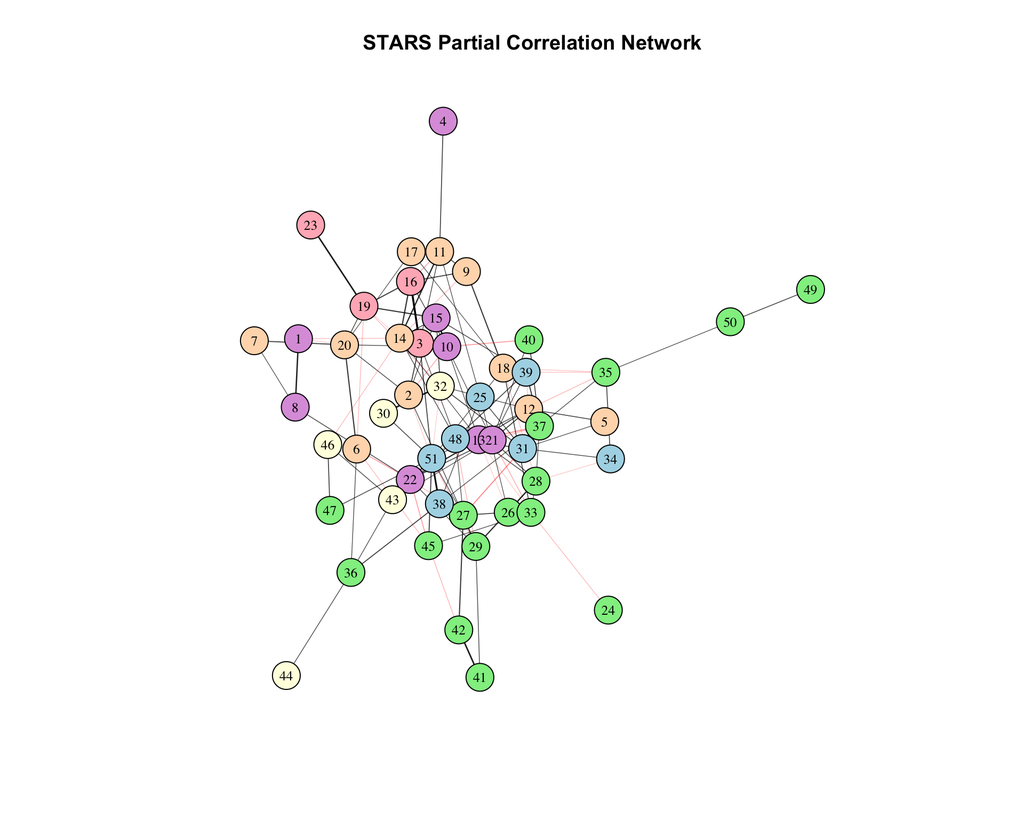

```r
# plot customizations
# pull items with higher correlations closer together
layout_inv <- layout_with_fr(stars_uw, weights = abs(E(stars_uw)$weight))

# plot edges with higher correlations in a darker shade
edge_colors <- ifelse(
  E(stars_uw)$weight > 0,
  rgb(0, 0, 0, alpha = scales::rescale(E(stars_uw)$weight, c(0.2, 1))),
  rgb(1, 0, 0, alpha = scales::rescale(abs(E(stars_uw)$weight), c(0.2, 1)))
)

# add colors for each factor and create a legend
factor_colors <- c(
  "Test_Class"     = "lightpink",
  "Interpretation" = "lightyellow",
  "Ask_for_Help"   = "peachpuff",
  "Worth"          = "lightblue",
  "Fear_Teachers"  = "plum",
  "Self_Concept"   = "lightgreen"
)

# map colors to vertices
vertex_colors <- factor_colors[V(stars_uw)$factor]

# Plot ---
plot(
  stars_uw,
  layout = layout_inv,
  main = "STARS Partial Correlation Network",
  vertex.color = factor_colors[V(stars_uw)$factor],
  vertex.label = V(stars_uw),
  vertex.label.color = "black", vertex.label.cex = 0.8,
  # vertex.frame.color = NA,
  vertex.size = 10,
  edge.width = abs(E(stars_uw)$weight) * 3,
  edge.color = edge_colors
)
```

# RQ2

Question: Which components of statistical anxiety are most central within the system, and therefore likely to be influential in maintaining overall anxiety?

## 1. Calculate strength centrality of all nodes and see nodes with the top 5 highest centrality values

```r
strength_vals <- strength(stars_uw, weights = abs(E(stars_uw)$weight))
top_strength <- sort(strength_vals, decreasing = TRUE)[1:5]
top_strength
```

```
##      Q51      Q21      Q14      Q22      Q13
## 3.869764 2.807016 2.733505 2.534361 2.416943
```

```r
(top_strength - mean(strength_vals)) / sd(strength_vals)
```

```
##      Q51      Q21      Q14      Q22      Q13
## 3.110728 1.765525 1.672477 1.420404 1.271779
```

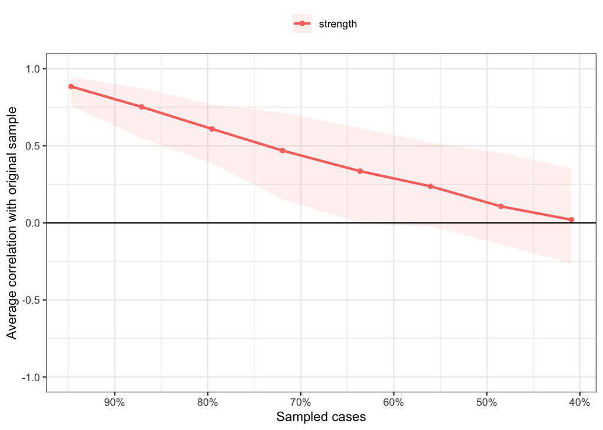

```r
# This takes a while to run so I will load the output instead
# boot_strength <- bootnet(
#   stars_matrix,
#   nBoots = 1000,
#   type = "case",
#   statistics = "strength"
# )
#
# save(boot_strength, file = "boot_strength.RData")

load("boot_strength.RData")

plot(boot_strength, "strength")
```

```r
cs_strength <- corStability(boot_strength)
```

```
## === Correlation Stability Analysis ===
##
## Sampling levels tested:
##   nPerson Drop%   n
## 1      54  59.1 106
## 2      64  51.5 105
## 3      74  43.9 148
## 4      84  36.4 133
## 5      95  28.0 144
## 6     105  20.5 131
## 7     115  12.9 129
## 8     125   5.3 104
##
## Maximum drop proportions to retain correlation of 0.7 in at least 95% of the samples:
##
## strength: 0.053 (CS-coefficient is lowest level tested)
##   - For more accuracy, run bootnet(..., caseMin = 0, caseMax = 0.129)
##
## Accuracy can also be increased by increasing both 'nBoots' and 'caseN'.
```

```r
cs_strength
```

```
##  strength
## 0.0530303
```

Items 51, 21, 14 and 22 and 13 have the highest strength centralities.

- 51. I am too slow in my thinking to get through statistics
- 21. Enrolling in a statistics course
- 14. Determining whether to reject or retain the null hypothesis
- 22. Going over a ﬁnal examination in statistics after it has been marked
- 13. Finding that another student in class got a diﬀerent answer than I did to a statistical problem

Stability of strength centrality is very low (0.053). The ranking is descriptively useful but unstable, suggesting that the identification of highly central items is sensitive to sampling variability.

```r
# option2 - not used as it fragmented the network
stars_adj_mat_pos <- ifelse(stars_adj_mat > 0, stars_adj_mat, 0) # only positive correlations are kept

stars_uw_posonly <- graph_from_adjacency_matrix(stars_adj_mat_pos, mode = 'undirected', weighted=TRUE)
summary(stars_uw_posonly)
```

```
## IGRAPH f35558c UNW- 51 92 --
## + attr: name (v/c), weight (e/n)
```

```r
components(stars_uw_posonly)$no
```

```
## [1] 2
```

```r
components(stars_uw_posonly)$csize
```

```
## [1] 50  1
```

## 2. Identify nodes with high bridge centrality, i.e. bridge multiple factors.

```r
stars_bridge <- bridge(
  stars_uw,
  communities = V(stars_uw)$factor
)

bridge_strength <- stars_bridge$`Bridge Strength`
top_bridge <- sort(bridge_strength, decreasing = TRUE)[1:5]
top_bridge
```

```
##      Q51      Q14      Q21      Q12      Q22
## 3.049727 2.087565 2.056560 1.804603 1.624784
```

```r
(top_bridge - mean(bridge_strength)) / sd(bridge_strength)
```

```
##      Q51      Q14      Q21      Q12      Q22
## 3.400239 1.911158 1.863172 1.473234 1.194938
```

Q51, Q14, Q21, Q12, Q22.

# RQ3

Question: Does a network-based key-player approach identify more structurally influential intervention targets than a latent-factor-based approach?

## 1. Use key player analysis

Compare a network-based key-player strategy with a latent-factor-based targeting strategy.

```r
stars_adj_mat_unweighted <- ifelse(stars_adj_mat > 0, 1, 0) # only positive correlations are kept

set.seed(1)
stars_kp <- kpset(
  adj.matrix = stars_adj_mat_unweighted,
  size = 3,
  type = "diffusion",
  method = "union",
  T = 1,
  binary = TRUE
)

stars_kp
```

```
## $keyplayers
## [1] 15 28 51
##
## $centrality
## [1] 22
```

```r
stars_kp_nodes <- colnames(stars_adj_mat_unweighted)[stars_kp$keyplayers]
stars_kp_coverage <- stars_kp$centrality / (ncol(stars_adj_mat_unweighted) - length(stars_kp$keyplayers))
stars_kp_nodes
```

```
##   Q15   Q28   Q51
## "Q15" "Q28" "Q51"
```

```r
stars_kp_coverage
```

```
## [1] 0.4583333
```

```r
n_sims <- 100

stars_kpsets <- character(n_sims)
stars_kpcoverage <- numeric(n_sims)

# for (i in 1:1000) {
#   set.seed(i)
#   kp <- kpset(
#     adj.matrix = stars_adj_mat_unweighted,
#     size = 3,
#     type = "diffusion",
#     method = "union",
#     T = 1,
#     binary = TRUE
#   )
#
#   # store set as sorted string
#   stars_kpsets[i] <- paste(
#     sort(colnames(stars_adj_mat_unweighted)[kp$keyplayers]),
#     collapse = ", "
#   )
#   stars_kpcoverage[i] <- kp$centrality / (ncol(stars_adj_mat_unweighted) - 3)
# }

# save(stars_kpsets,stars_kp_coverage,file="kpresults.RData")
load("kpresults.RData")

table(stars_kpsets) # stable across seeds
```

```
## stars_kpsets
## Q15, Q28, Q51
##           100
```

```r
mean(stars_kpcoverage)
```

```
## [1] 0
```

Key Players Identified: Q15, Q28, Q51 0.4583333

## 2. Identify the latent factor with the highest mean item score, then assess the reach of targeting its strongest components.

1. get top latent factor

```r
factor_loadings <- list(
  Test = c(Q1=.81, Q4=.64, Q8=.81, Q10=.74, Q13=.55, Q15=.74, Q21=.64, Q22=.57),
  Interpretation = c(Q2=.66, Q5=.72, Q6=.72, Q7=.60, Q9=.46, Q11=.71, Q12=.55, Q14=.67, Q17=.42, Q18=.54, Q20=.75),
  Ask_for_Help = c(Q3=.85, Q16=.94, Q19=.68, Q23=.48),
  Worth = c(Q24=.52, Q26=.73, Q27=.71, Q28=.76, Q29=.81, Q33=.78, Q35=.63, Q36=.51, Q37=.74, Q40=.80, Q41=.68, Q42=.81, Q45=.60, Q47=.67, Q49=.74, Q50=.85),
  Teacher = c(Q30=.77, Q32=.66, Q43=.80, Q44=.60, Q46=.71),
  Self_Concept = c(Q25=.58, Q31=.73, Q34=.75, Q38=.80, Q39=.67, Q48=.51, Q51=.80)
)

item_means <- colMeans(data.items, na.rm = TRUE)

latent_df <- do.call(rbind, lapply(names(factor_loadings), function(f) {
  data.frame(
    latent_factor = f,
    node = names(factor_loadings[[f]]),
    loading = as.numeric(factor_loadings[[f]]),
    mean = item_means[names(factor_loadings[[f]])]
  )
}))
latent_df
```

|  | latent_factor | node | loading | mean |
| --- | --- | --- | --- | --- |
| Q1 | Test | Q1 | 0.81 | 3.750000 |
| Q4 | Test | Q4 | 0.64 | 3.106061 |
| Q8 | Test | Q8 | 0.81 | 4.189394 |
| Q10 | Test | Q10 | 0.74 | 3.628788 |
| Q13 | Test | Q13 | 0.55 | 3.477273 |
| Q15 | Test | Q15 | 0.74 | 3.409091 |
| Q21 | Test | Q21 | 0.64 | 2.522727 |
| Q22 | Test | Q22 | 0.57 | 3.295455 |
| Q2 | Interpretation | Q2 | 0.66 | 2.507576 |
| Q5 | Interpretation | Q5 | 0.72 | 2.454545 |

[output cut: 41 more lines]

```r
factor_summary <- latent_df %>%
  group_by(latent_factor) %>%
  summarise(mean_factor = mean(mean), .groups = "drop") %>%
  arrange(desc(mean_factor))

factor_summary
```

| latent_factor | mean_factor |
| --- | --- |
| Test | 3.422348 |
| Self_Concept | 2.756494 |
| Ask_for_Help | 2.581439 |
| Interpretation | 2.335399 |
| Teacher | 2.178788 |
| Worth | 2.121129 |

```r
best_factor <- factor_summary$latent_factor[1]
```

2. get top 3 components from top latent factor based on average score (in dataset) + factor loading. calculate reach if these 3 components are targetted.

```r
top3_latent <- latent_df %>%
  filter(latent_factor == best_factor) %>%
  mutate(score = as.numeric(scale(mean)) + as.numeric(scale(loading))) %>%
  arrange(desc(score)) %>%
  slice(1:3)

top3_latent
```

|  | latent_factor | node | loading | mean | score |
| --- | --- | --- | --- | --- | --- |
| Q8 | Test | Q8 | 0.81 | 4.189394 | 2.7734506 |
| Q1 | Test | Q1 | 0.81 | 3.750000 | 1.8730463 |
| Q10 | Test | Q10 | 0.74 | 3.628788 | 0.9380165 |

```r
top3_latent_nodes <- top3_latent$node
top3_latent_nodes
```

```
## [1] "Q8"  "Q1"  "Q10"
```

```r
coverage_score <- function(adj_bin, nodes) {
  idx <- match(nodes, colnames(adj_bin))
  neighbors <- which(colSums(adj_bin[idx, , drop = FALSE]) > 0)
  covered <- setdiff(neighbors, idx)
  length(covered) / (ncol(adj_bin) - length(idx))
}

latent_top3_coverage <- coverage_score(stars_adj_mat_unweighted, top3_latent_nodes)
latent_top3_coverage
```

```
## [1] 0.1458333
```

Reach = 0.146

## 3. Set a random benchmark for 3 random node sets to perform stats test.

```r
set.seed(123)

random_sets <- replicate(
  1000,
  sample(colnames(stars_adj_mat_unweighted), 3, replace = FALSE),
  simplify = FALSE
)

random_coverage <- sapply(random_sets, function(x) coverage_score(stars_adj_mat_unweighted, x))

random_mean <- mean(random_coverage)
random_sd <- sd(random_coverage)
random_max <- max(random_coverage)

print("Statistics on coverage of randomly selected nodes")
```

```
## [1] "Statistics on coverage of randomly selected nodes"
```

```r
print(paste("Mean:",random_mean))
```

```
## [1] "Mean: 0.201604166666667"
```

```r
print(paste("SD:", random_sd))
```

```
## [1] "SD: 0.0586546122706813"
```

```r
# empirical benchmark: proportion of random sets with lower coverage
stars_kp_coverage <- mean(stars_kpcoverage)
print(paste("p-value for KP analysis:",mean(random_coverage >= stars_kp_coverage)))
```

```
## [1] "p-value for KP analysis: 1"
```

```r
print(paste("p-value for latent factor analysis",mean(random_coverage >= latent_top3_coverage)))
```

```
## [1] "p-value for latent factor analysis 0.886"
```

```r
diff_kp <- stars_kp_coverage - mean(random_coverage)
z_kp <- diff_kp / sd(random_coverage)
print(paste("Z-value for KP analysis:", z_kp))
```

```
## [1] "Z-value for KP analysis: -3.43714089756995"
```

## RQ3a: Additional analyses stability of bootstrap estimates

```r
set.seed(123)

n_boot <- 100

# bootstrap 100 stars networks based on data
# stars_kp_boot_nodes <- vector("list", n_boot)
# stars_kp_boot_coverage <- numeric(n_boot)
#
# for (i in 1:n_boot) {
#
#   # 1. resample participants with replacement
#   boot_data <- data.items[sample(nrow(data.items), replace = TRUE), ]
#
#   # 2. estimate network on bootstrap sample
#   boot_matrix <- estimateNetwork(
#     boot_data,
#     default = "pcor",
#     threshold = "sig"
#   )
#
#   W_boot <- boot_matrix$graph
#
#   stars_adj_mat_unweighted <- ifelse(W_boot > 0, 1, 0)
#   diag(stars_adj_mat_unweighted) <- 0
#
#   colnames(stars_adj_mat_unweighted) <- colnames(boot_data)
#   rownames(stars_adj_mat_unweighted) <- colnames(boot_data)
#
#   stars_kp <- kpset(
#     adj.matrix = stars_adj_mat_unweighted,
#     size = 3,
#     type = "diffusion",
#     method = "union",
#     T = 1,
#     binary = TRUE
#   )
#
#   stars_kp_nodes <- colnames(stars_adj_mat_unweighted)[stars_kp$keyplayers]
#   stars_kp_boot_nodes[[i]] <- stars_kp_nodes
#
#   stars_kp_coverage <- stars_kp$centrality /
#     (ncol(stars_adj_mat_unweighted) - length(stars_kp$keyplayers))
#
#   stars_kp_boot_coverage[i] <- stars_kp_coverage
# }
#
# save(stars_kp_boot_nodes,stars_kp_boot_coverage,file="stars_kp_boot.RData")
load("stars_kp_boot.RData")

stars_kp_freq <- table(unlist(stars_kp_boot_nodes)) %>%
  sort(decreasing = TRUE)
stars_kp_freq_df <- data.frame(
  node = names(stars_kp_freq),
  freq = as.numeric(stars_kp_freq)
) %>%
  as_tibble() %>%
  mutate(prop = freq / n_boot)
stars_kp_freq_df
```

| node | freq | prop |
| --- | --- | --- |
| Q51 | 26 | 0.26 |
| Q16 | 14 | 0.14 |
| Q27 | 14 | 0.14 |
| Q8 | 14 | 0.14 |
| Q12 | 12 | 0.12 |
| Q6 | 12 | 0.12 |
| Q15 | 9 | 0.09 |
| Q2 | 9 | 0.09 |
| Q31 | 9 | 0.09 |
| Q37 | 9 | 0.09 |

[output cut: 41 more lines]

```r
mean(stars_kp_boot_coverage)
```

```
## [1] 0.6389583
```

```r
sd(stars_kp_boot_coverage)
```

```
## [1] 0.06399414
```

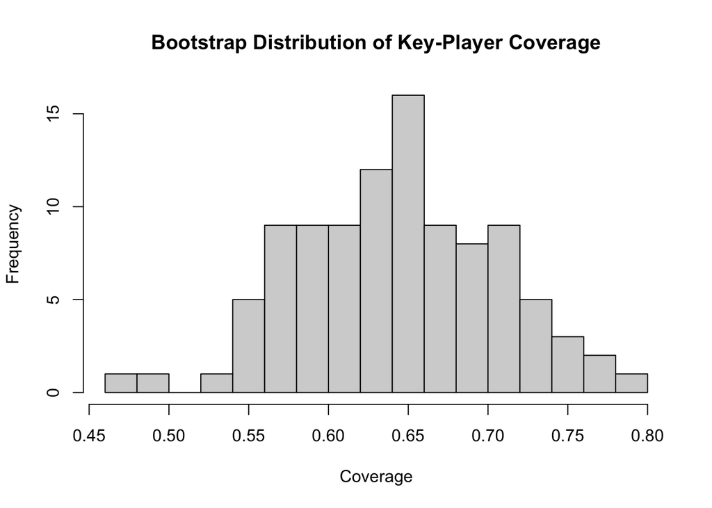

```r
hist(
  stars_kp_boot_coverage,
  main = "Bootstrap Distribution of Key-Player Coverage",
  xlab = "Coverage",
  breaks = 15
)
```